# Uso de redes neurais para a identificação de frutas parecidas

## Introdução

Este trabalho propõe uma análise sobre o uso de redes neurais para classificar frutas que são parecidas visualmente mas que são de diferentes tipos, criando assim um classificador de frutas. Para a realização desta tarefa foi utilizado a base de dados *Fruits 360*, que é uma base de dados que possui fotos de frutas, esta base esta disponível em: https://www.kaggle.com/moltean/fruits

Este trabalho apresenta uma pequena descrição sobre as frutas utilizadas, uma análise sobre os histogramas de cor para as fotos das frutas utilizadas, uma pequena descrição do tipo de rede neural utilizada para criar o classificador, códigos utilizados para a criação do classificador e uma análise sobre a eficiência que o classificador criado possui.

Os códigos e artefatos utilizados para a realização deste trabalho podem ser obtidos em: https://rebrand.ly/7sv33x

## Elementos da base de dados utilizados para a análise

As frutas utilizadas para esta análise são de três diferentes tipos de tomate e para classificar de que tipo é cada tomate foram utilizados dados extraídos apenas de suas fotos. Um detalhe importante sobre a base de dados utilizada é que ela pode ter até três fotos de um mesmo tomate com cada foto sendo tirada de um ângulo diferente, com estes ângulos sendo fixos. As fotos utilizadas para esta análise possuem 100 pixels de comprimento por 100 pixels de altura.

|  | Ângulo 1 | Ângulo 2 | Ângulo 3 |
| --- | --- | --- | --- |
| Tipo 1 |  |  |  |
| Tipo 2 |  |  |  |
| Tipo 3 |  |  |  |

### Análise sobre as fotos de tomate utilizadas

A seguir estão as médias e desvios padrão para os vários histogramas de cores das fotos que um determinado tipo de tomate possuí.

Canal azul

Canal verde

Canal vermelho

Tomate tipo 1

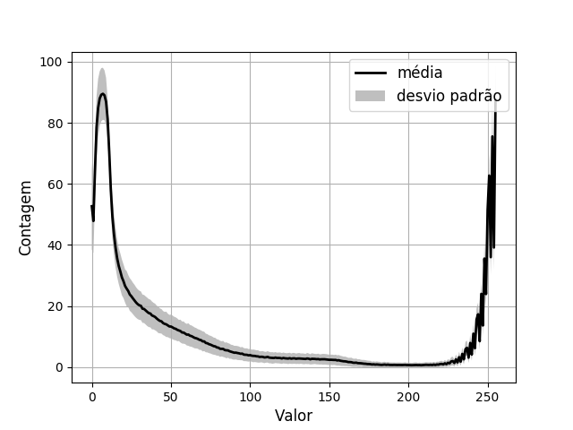

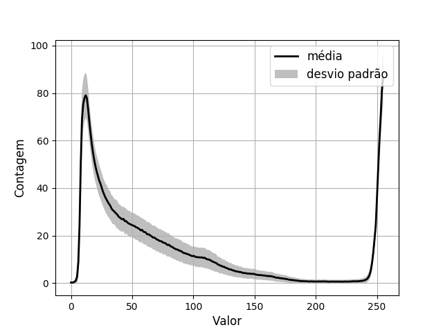

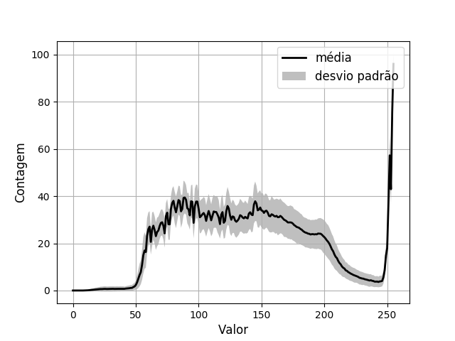

Tomate tipo 2

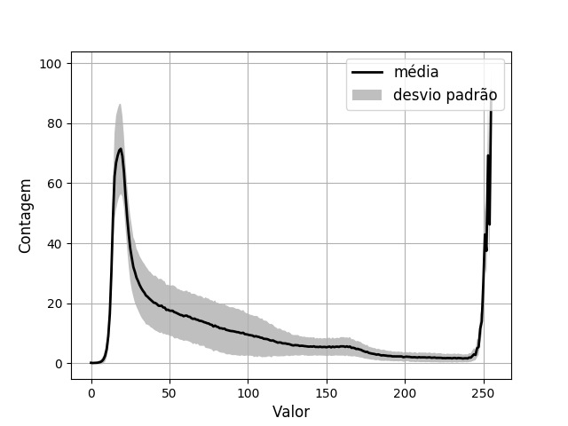

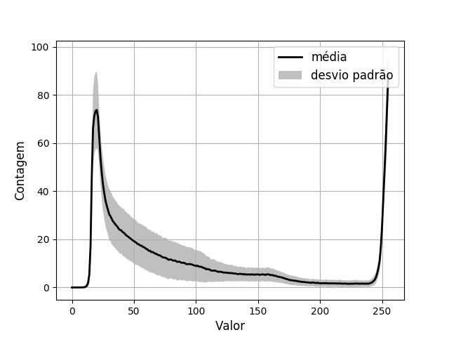

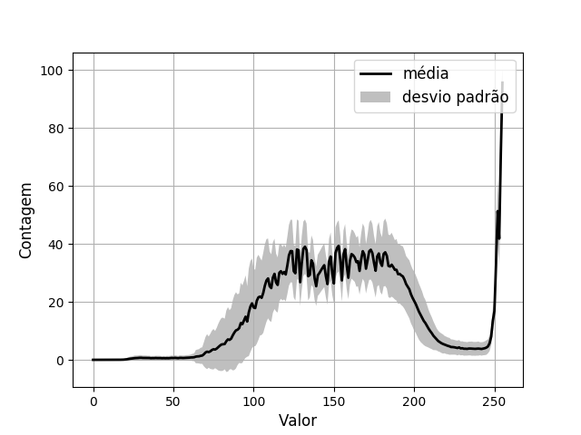

Tomate tipo 3

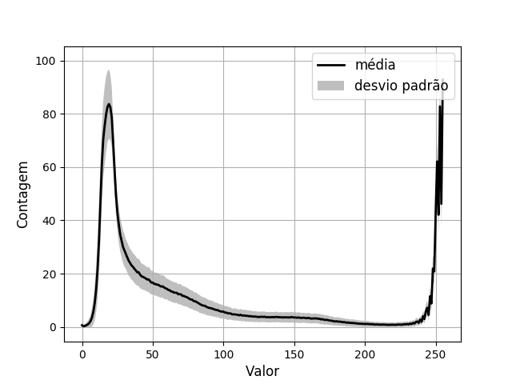

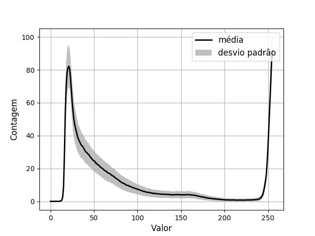

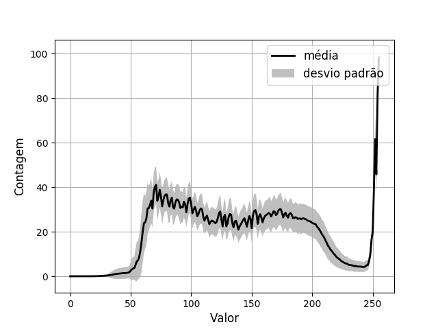

```python
import cv2
import os
import numpy as np
import matplotlib.cbook as cbook
import matplotlib.pyplot as plt
from IPython.display import display, HTML
#%matplotlib inline
#%matplotlib autp
def loadImagesFromADataBase(folderWithObjects):
    imgs=[]
    for src in os.listdir(folderWithObjects):
         imgs.append(np.array(cv2.imread(folderWithObjects+src)))

    return imgs

def computeHistogram(imgChannel):
    hist=np.zeros(256)
    for x in imgChannel:
        hist[x]=hist[x]+1.0

    return hist

def computeAvg(histsList):
    histAvg=np.zeros(256)
    for i in range(256):
        histAvg[i]=np.mean(histsList[:,i])

    return histAvg

def computeSTD(histsList):
    histSTD=np.zeros(256)
    for i in range(256):
        histSTD[i]=np.std(histsList[:,i])

    return histSTD
def getAvgAndStdForTheValuesFromHistrogramsOfImagesStoredOnADirectory(directory,channelForTheHistograms):
    imgs=loadImagesFromADataBase(directory)
    hists=[]
    for img in imgs:
        hists.append(computeHistogram(img[:,:,channelForTheHistograms]))

    hists=np.array(hists)
    histsAvg=computeAvg(hists)
    histsSTD=computeSTD(hists)

    lower_bound=histsSTD
    upper_bound=histsSTD
    fig, ax = plt.subplots(1,1)
    trash=ax.plot(list(range(256)), histsAvg, lw=2, label="média", color='black', ls='-')
    trash=ax.fill_between(list(range(256)), histsAvg+upper_bound,histsAvg-lower_bound, facecolor='gray', alpha=0.5,label='desvio padrão')
    trash=ax.legend(loc='upper right', fontsize = 12)

    trash=ax.set_xlabel('Valor',  fontsize = 12)
    trash=ax.set_ylabel('Contagem',fontsize = 12)
    trash=ax.grid()
    from io import BytesIO
    figfile = BytesIO()
    trash=plt.savefig(figfile, format='png')
    figfile.seek(0)  # rewind to beginning of file
    import base64

    figdata_png = str(base64.b64encode(figfile.getvalue()))[2:-1]
    return figdata_png

figdata_png=getAvgAndStdForTheValuesFromHistrogramsOfImagesStoredOnADirectory("dataset/training/Tomato1/",1)
htmlTORender='<table>'
htmlTORender=htmlTORender+'<tr style="background: #fff;">'
htmlTORender=htmlTORender+'<td> </td>'
htmlTORender=htmlTORender+'<td style="text-align:center">Canal azul</td>'
htmlTORender=htmlTORender+'<td style="text-align:center">Canal verde</td>'
htmlTORender=htmlTORender+'<td style="text-align:center">Canal vermelho</td>'
htmlTORender=htmlTORender+'</tr>'
for typeOfTomato in range(1,4):
    htmlTORender=htmlTORender+'<tr style="background: #fff;">'
    htmlTORender=htmlTORender+'<td> Tomate tipo '+str(typeOfTomato)+' </td>'
    for channel in range(3):
        figdata_png=getAvgAndStdForTheValuesFromHistrogramsOfImagesStoredOnADirectory("dataset/training/Tomato"+str(typeOfTomato)+"/",channel)
        htmlTORender=htmlTORender+'<td> <img src="data:…'+figdata_png+'"> </td>'
    htmlTORender=htmlTORender+'</tr>'


htmlTORender=htmlTORender+'</table>'
display(HTML(htmlTORender))
```

Observando tabela acima pode-se notar que os histogramas para o canal de cor vermelho das imagens são os que mais mudam de forma, isto faz sentido porque o vermelho é a cor principal dos tomates analisados. Para um estudo mais aprofundado dos histogramas do canal de cor vermelho foram criados *boxplots* com a distribuição dos diferentes valores de *thresholding* de Otsu que estes histogramas possuem, cada *boxplot* agrupa a distribuição de valores para um tipo de tomate. O *thresholding* de Otsu é uma medida muito utilizada em visão computional e processamento de imagens, ele consiste em achar em um histograma o ponto de corte para binarizar uma imagem. A seguir estão os *boxplots* mencionados:

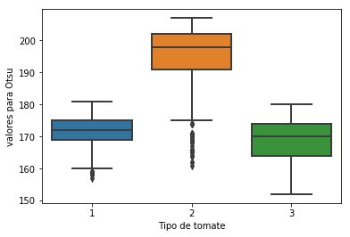

```python
from skimage import data
from skimage import filters
from skimage import exposure
import seaborn as sns
import pandas as pd

hists=[]
channelForTheHistograms=2
otsuValues=[]

classForImages=[]

imgs=loadImagesFromADataBase("dataset/training/Tomato1/")
for img in imgs:
     otsuValues.append(filters.threshold_otsu(img[:,:,channelForTheHistograms]))
     classForImages.append("1")

imgs=loadImagesFromADataBase("dataset/training/Tomato2/")
for img in imgs:
     otsuValues.append(filters.threshold_otsu(img[:,:,channelForTheHistograms]))
     classForImages.append("2")


imgs=loadImagesFromADataBase("dataset/training/Tomato3/")
for img in imgs:
     otsuValues.append(filters.threshold_otsu(img[:,:,channelForTheHistograms]))
     classForImages.append("3")

df=pd.DataFrame(data={'Tipo de tomate':classForImages,'valores para Otsu':otsuValues})
sns.boxplot(x="Tipo de tomate", y="valores para Otsu", data=df,linewidth=2)
```

Observando os *boxplots* pode-se observar que o valor *thresholding* de Otsu é bom para diferenciar o tipo dois de tomate do tipo um e três, porém não é possível diferenciar o tipo um de tomate do tipo três. Portanto o *thresholding* de Otsu é bom apenas para classificar se um tomate é do tipo 2.

## Rede neural utilizada

Para a criação e utilização do classificador criado não são considerados o angulo da foto tirada e nem se um mesmo tomate possui varias fotos, apenas é fornecido uma foto qualquer e o classificador infere o tipo de tomate que esta na foto.

## Códigos de programação utilizada para o carregamento da base de dados

```python
import cv2
import os
import numpy as np
def appendObjectsToDataset(dataset,folderWithObjects,labelForTheObjects):
    for src in os.listdir(folderWithObjects):
        dataset['x'].append( np.array(cv2.imread(folderWithObjects+src),dtype=float)/255.0)
        dataset['y'].append(labelForTheObjects)



tomatoTraining={"x":[],"y":[]}
appendObjectsToDataset(tomatoTraining,"dataset/training/Tomato1/",[0,0,1])
appendObjectsToDataset(tomatoTraining,"dataset/training/Tomato2/",[0,1,0])
appendObjectsToDataset(tomatoTraining,"dataset/training/Tomato3/",[1,0,0])
tomatoTest={"x":[],"y":[]}
appendObjectsToDataset(tomatoTest,"dataset/test/Tomato1/",[0,0,1])
appendObjectsToDataset(tomatoTest,"dataset/test/Tomato2/",[0,1,0])
appendObjectsToDataset(tomatoTest,"dataset/test/Tomato3/",[1,0,0])
```

## Códigos de programação utilizados para a criação de um classificador com base em redes neurais

```python
trainNeuralNetwork=False #coloque o valor como sendo true se quizer treinar uma rede neural.
```

### Código em comum que vai ser utilizado para a criação, treinamento e utilização da rede neural

```python
# importar pacotes necessários
from keras.models import Sequential
from keras.layers.core import Flatten
from keras.layers.core import Dense
from keras.layers.convolutional import Conv2D
from keras.layers.convolutional import MaxPooling2D
from keras.layers.core import Activation
from keras.utils import to_categorical
from keras.optimizers import SGD
from keras import backend
from sklearn.datasets import fetch_mldata
from sklearn.model_selection import train_test_split
from sklearn.metrics import classification_report
import tensorflow as tf
```

### Criação e treinamento da rede neural para a classificação de tomates com base em fotos

Para a criação de um classificador a partir de uma rede neural é preciso treina-la. A rede neural foi treinada com o conjunto de treinamento da base de dados, este conjunto possui 2148 fotos.

```python
from keras.models import load_model

def createModel(height,width,channels,nclass):
    inputShape = (height, width, channels)

    model = Sequential()
    model.add(Conv2D(6, (5, 5), padding="same",input_shape=inputShape))
    model.add(Activation("relu"))
    model.add(MaxPooling2D((2,2)))
    model.add(Conv2D(16, (5, 5)))
    model.add(Activation("relu"))
    model.add(MaxPooling2D((2,2)))
    model.add(Flatten())
    model.add(Dense(384))
    model.add(Activation("relu"))
    model.add(Dense(160))
    model.add(Activation("relu"))
    model.add(Dense(160))
    model.add(Activation("relu"))
    model.add(Dense(160))
    model.add(Activation("relu"))
    model.add(Dense(nclass))
    model.add(Activation("softmax"))
    model.compile(optimizer=SGD(0.01), loss="categorical_crossentropy",
              metrics=["accuracy"])

    return model


config = tf.ConfigProto(allow_soft_placement=True, log_device_placement=False)
config.gpu_options.allow_growth = True
model=None
with tf.Session(config=config) as sess:
    model=createModel(np.shape(tomatoTraining['x'][0])[0],np.shape(tomatoTraining['x'][0])[1],np.shape(tomatoTraining['x'][0])[2],3)
    if(trainNeuralNetwork==True):
        model.fit(np.array(tomatoTraining['x']), np.array(tomatoTraining['y']), batch_size=128, epochs=200)
        model.save('model_created.hdf5')
```

## Utilização da rede neural para a predição dos tipos de tomate com base em fotos

Para um teste de acurácia do classificador criado utilizou-se o conjunto de teste da base de dados, este conjunto possui 717 fotos.

```python
predictedClassFromModel=None
with tf.Session(config=config) as sess:
    model= load_model('model_created.hdf5')
    tomatoTest['predicted']=model.predict(np.array(tomatoTest['x']))
```

### Resultados obtidos

A seguir esta uma matriz de confusão com qual se pode analisar os resultados obtidos pelo classificador criado.

```python
from sklearn.metrics import confusion_matrix
def positionWithMaxValueFromAVector(vector):
    valueToSearch=max(vector)
    i=0
    for x in vector:
        if(x==valueToSearch):
            return i
        i=i+1

    return -1
predictedClassFromModel=list(map(positionWithMaxValueFromAVector,tomatoTest['predicted'] ))
yReal=list(map(positionWithMaxValueFromAVector, tomatoTest['y']))
pd.DataFrame(confusion_matrix(yReal,predictedClassFromModel),columns=[['predito','predito','predito'],['Tipo 1','Tipo 2','Tipo 3']], index=[['real','real','real'],['Tipo 1','Tipo 2','Tipo 3']])
#pd.DataFrame(confusion_matrix(yReal,yPredicted), columns=['y_Actual','y_Predicted'])
```

|  |  | predito Tipo 1 | predito Tipo 2 | predito Tipo 3 |
| --- | --- | --- | --- | --- |
| real | Tipo 1 | 216 | 30 | 0 |
|  | Tipo 2 | 0 | 225 | 0 |
|  | Tipo 3 | 0 | 0 | 246 |

Como pode-se observar pela matriz de confusão o classificador criado a partir de redes neurais apresentou uma boa acurácia, aproximadamente 95%, onde apenas alguns tomates do tipo um foram classificados erroneamente como sendo do tipo dois. Talvez aumentando o número de neurônios da rede fosse possível obter uma acurácia melhor, isto é uma proposta interessante de projeto futuro.

## Conclusão

Este trabalho apresentou uma análise sobre o uso de redes neurais convolucionais para a criação de um classificador que identifique diferentes tipos de tomate com base em fotos. Os resultados obtidos mostram que este tipo de rede neural criou um classificador com grande acurácia.